# Applying pySCA for any protein of interest, part II

### Created by Thuy N. Nguyen, 191202

These notebooks are intended to supplement pySCA documentation here: https://ranganathanlab.gitlab.io/pySCA/install/

The goal of these general_pySCA usage notebooks is for users to be able to easily apply SCA to their protein of interest. In the first part, the user processed their multiple sequence alignment, performed the SCA calculations, and evaluated whether or not their MSA is appropriate for further analysis and sector identification.

In this second part, the user will take the variables from part I to (1) decompose the matrix of co-evolution ($C_{ij}$) using linear algebra methods: Eigendecomposition and Independent Components Analysis (ICA), (2) use this decomposition identify the most significantally co-evolving groups of amino acids, and (3) identify which species contribute to these co-evolving amino acids using a linear algebra method called the Singular Value Decomposition.

```python
#####this defaults plots to matplotlib 1.0 formatting
import matplotlib.style
import matplotlib as mpl
import matplotlib.pyplot as plt
#mpl.style.use('classic')
%matplotlib inline
mpl.rcParams['figure.dpi']= 150

#import other modules you will need
import pickle as pickle
import numpy as np
import scipy.cluster.hierarchy as sch
import scipy.stats as stats

from pysca import scaTools as sca
```

## Importing data from part I

```python
pathPickle = '/Users/thuynguyen/Documents/pySCA/output/s1Ahalabi_1470_nosnakes.db'
db = pickle.load(open(pathPickle,'rb')) #db is a dictionary that stored the outputs in part I.

#let's redefine each dictionary to simplify the analysis.
Dseq = db['sequence'] #results of annotating and processing the  alignment
Dsca = db['sca'] #results of core SCA calculations
Dsect = db['sector'] #results of decomposition of the matrix of co-evolution between pairs of amino acids
```

## 1. The SCA matrix contains pair-wise co-evolution between positions in the amino acid sequence, $\tilde{C}_{ij}$

Let's visualize this matrix in a heatmap.

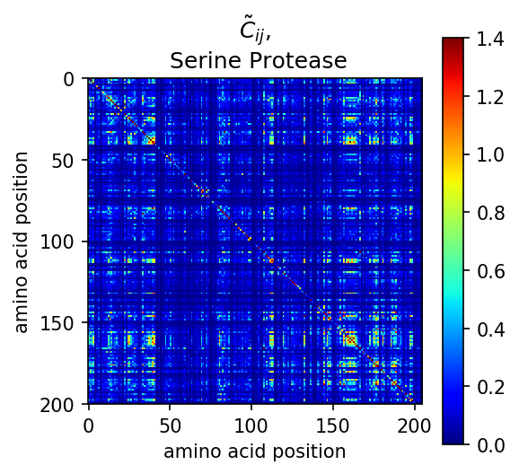

```python
### initialize variables for visualizing the SCA matrix ######

sca_matrix = Dsca['Csca'] #pull out Cij matrix

minCorrelation = 0
maxCorrelation = 1.4

title = '$\~C_{ij}$,\n Serine Protease' # change title of figure to whatever you want
###############################################################

plt.figure()
plt.title(title)
plt.imshow(sca_matrix,cmap = 'jet',vmin=minCorrelation,vmax=maxCorrelation,interpolation='none',aspect='equal')

plt.xlabel('amino acid position') #inserts legend
plt.ylabel('amino acid position')

plt.xticks(np.arange(0,len(Dseq['ats']),50)) #places an xtick every 50 positions on this axis
plt.yticks(np.arange(0,len(Dseq['ats']),50))

plt.colorbar() # Shows the legend
```

## 2. Eigendecomposition of the SCA matrix

scaCore calculated two matricies. The first contains positional co-evolution (the SCA matrix). The second is a randomized version of this matrix. Let's visualize this randomized matrix to make sure that the signal of co-evolution was successfully muted by randomization.

**This randomized matrix is a control against the SCA matrix to evaluate signficant positions from eigendecomposition.**

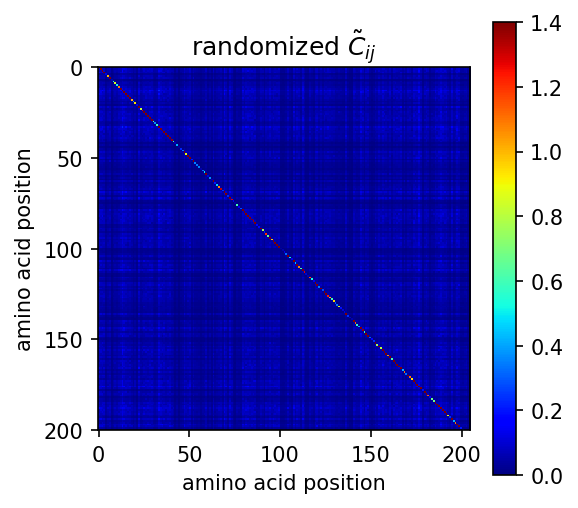

```python
plt.figure()
plt.title('randomized $\~ C_{ij}$')
plt.imshow(Dsca['Crand'],cmap = 'jet',vmin=minCorrelation,vmax=maxCorrelation,interpolation='none',aspect='equal')

plt.xlabel('amino acid position') #inserts legend
plt.ylabel('amino acid position')

plt.xticks(np.arange(0,len(Dseq['ats']),50)) #places an xtick every 50 positions on this axis
plt.yticks(np.arange(0,len(Dseq['ats']),50))

plt.colorbar() # Shows the legend
```

### **scaSectorID performed an eigendecomposition that factors both the SCA matrix and the randomized SCA matrix into LxL matricies of eigenvectors and eigenvalues (L is the number of eigenmodes). To determine the significant eigenmodes, the distribution of the randomized and unrandomized eigenvalues are plotted against each other. Eigenvalues outside of the randomized distribution are significant.**

```
Number of eigenmodes to keep is 6

cyan - distribution of eigenvalues of SCA matrix
red - distribution of eigenvalues from decomposition of randomized matrix
```

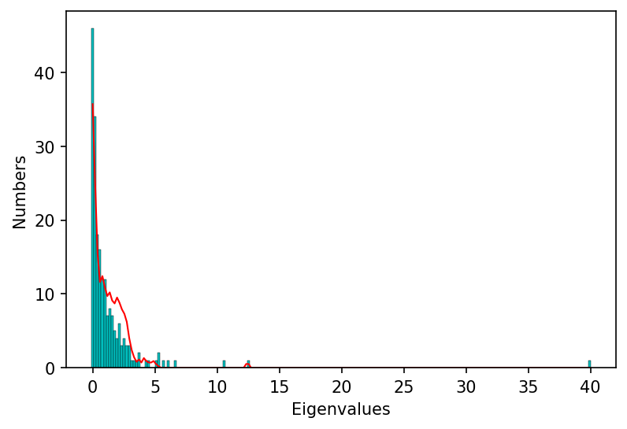

```python
plt.rcParams['figure.figsize'] = 6,4
#distribution of eigenvalues
hist0, bins = np.histogram(Dsca['Lrand'].flatten(), bins=Dseq['Npos'],range=(0,Dsect['Lsca'].max()))

hist1, bins = np.histogram(Dsect['Lsca'], bins=Dseq['Npos'],range=(0,Dsect['Lsca'].max()))

plt.bar(bins[:-1], hist1, np.diff(bins),color='c',edgecolor = 'k',linewidth = 0.2) #dist of eigenvalues

plt.plot(bins[:-1], hist0/Dsca['Ntrials'], 'r', linewidth=1)

plt.xlabel('Eigenvalues', fontsize=10)
plt.ylabel('Numbers', fontsize=10)

print('Number of eigenmodes to keep is %i' %(Dsect['kpos'])) #Dsect['kpos'] stores number of significant eigenmodes

#This is hard to see so zoom in
#plt.ylim(-0.5,5) #comment if you want to see the whole thing
#plt.xlim()

print ('')
print('cyan - distribution of eigenvalues of SCA matrix')
print('red - distribution of eigenvalues from decomposition of randomized matrix')
```

### For each significant eigenmode in kpos, the eigenvector is an array of N positions. Each value is the position's contribution of the signal of co-evolution to the eigenvector.

The figure below compares eigenvectors 1 & 2, 3 & 4, and 5 & 6.

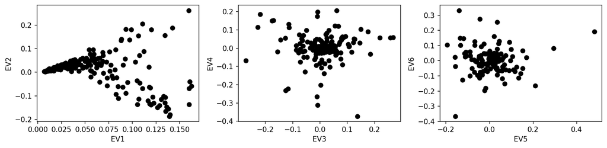

```python
plt.rcParams['figure.figsize'] = 12,3

plt.figure()
plt.title('Compare positional correlations between significant eigenvectors')

eigenvectors = Dsect['Vsca']
vectors2compare = [ [x,x+1] for x in range(0, Dsect['kpos']-1, 2)]
numFigColumns = len(vectors2compare)

for k, [k1,k2] in enumerate(vectors2compare):
    plt.subplot(1,numFigColumns,k+1)
    plt.plot(eigenvectors[:,k1],eigenvectors[:,k2],'ok')
    plt.xlabel('EV%i' % (k1+1))
    plt.ylabel('EV%i' % (k2+1))
plt.tight_layout()
```

## 3. Independent Components Analysis (ICA) maximizes independence between each eigenvector.

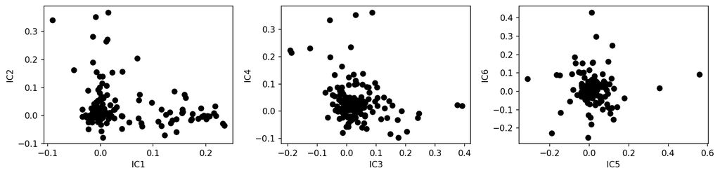

```python
plt.rcParams['figure.figsize'] = 12,3

plt.figure()
plt.title('Compare positional correlations between significant eigenvectors')

independentComponents = Dsect['Vpica']
vectors2compare = [ [x,x+1] for x in range(0, Dsect['kpos']-1, 2)]
numFigColumns = len(vectors2compare)

for k, [k1,k2] in enumerate(vectors2compare):
    plt.subplot(1,numFigColumns,k+1)
    plt.plot(independentComponents[:,k1],independentComponents[:,k2],'ok')
    plt.xlabel('IC%i' % (k1+1))
    plt.ylabel('IC%i' % (k2+1))
plt.tight_layout()
```

Conceptually, what ICA does is a rotation of the eigenvectors.

## 4. Identify significant positions in each top independent component (IC)

Like in each EV, each IC is an array of N positions. Each value is the contribution of the a given amino acid's positional correlation to the IC.

To define the positions with significant contributions to each of the independent components (ICs), we make a empirical fit for each IC to the t-distribution and select positions with greater than a specified cutoff on the CDF. We choose $p=0.95$ as our cutoff. Note that since some positions might contribute significantly to more than one IC (an indication of non-independence of ICs), we apply a simple algorithm to assign such positions to one IC. Specifically, we assign positions to the IC with which it has the greatest degree of co-evolution.

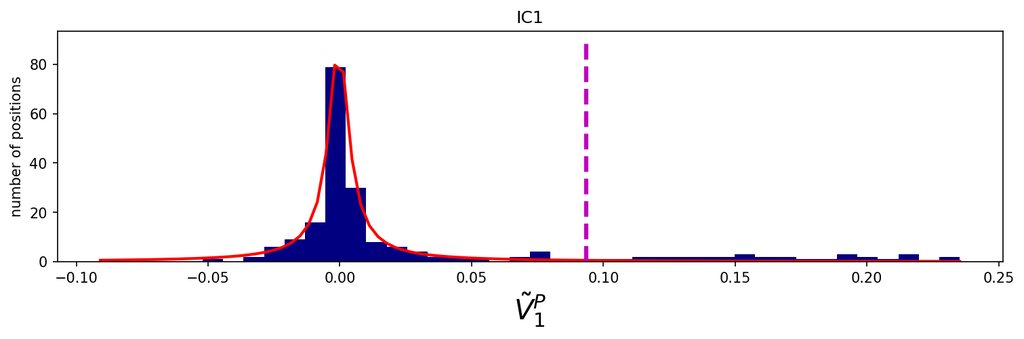

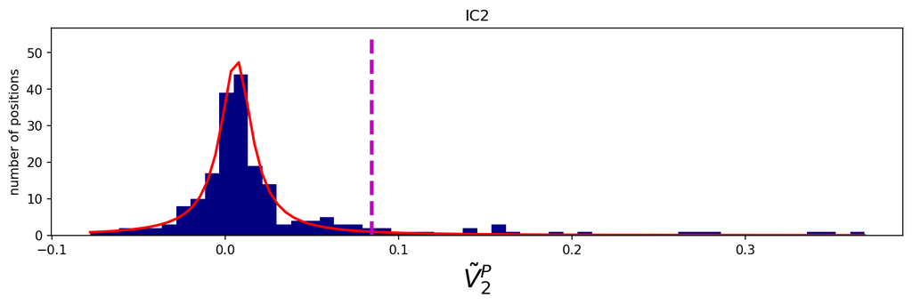

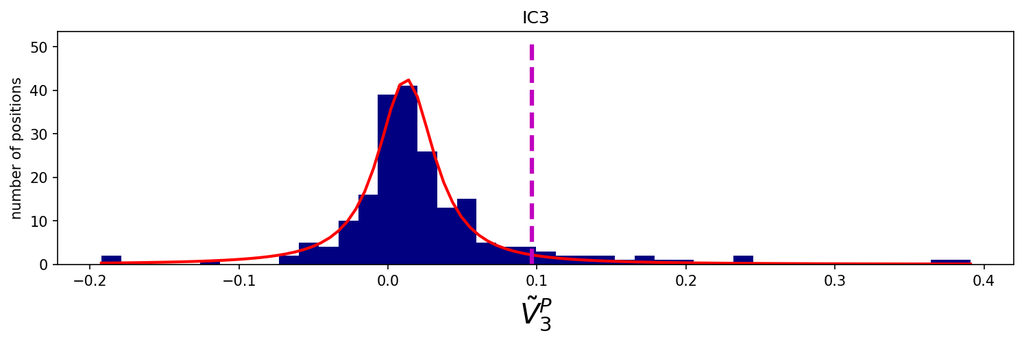

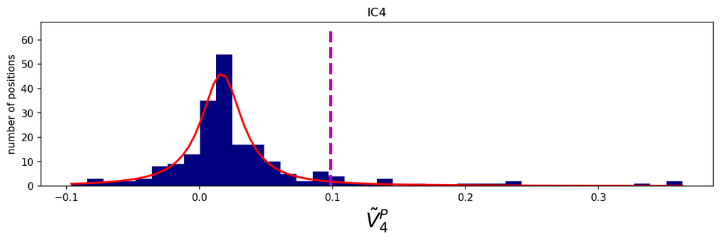

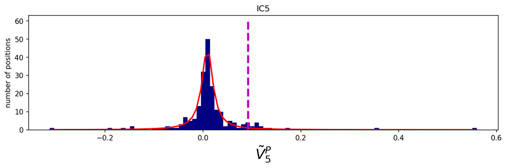

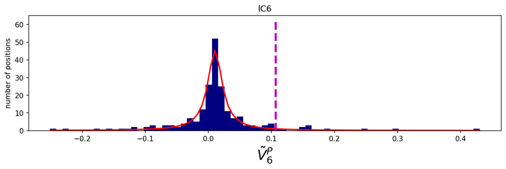

```python
# plot histogram of each IC
for k in range(Dsect['kpos']): #iterate through each significant IC

    # determine number of bins for the histogram based on interquartile range
    iqr = stats.scoreatpercentile(independentComponents[:,k],75) - stats.scoreatpercentile(independentComponents[:,k],25)
    binWidth = 2*iqr*(len(independentComponents[:,k])**(-0.33))
    nBins = int(round((max(independentComponents[:,k]) - min(independentComponents[:,k]))/binWidth))

    #plot histogram of values in each IC
    plt.figure()
    h_params = plt.hist(independentComponents[:,k], nBins,color = 'navy')
        #output of histogram are the height of each bin and their x-positions

    # plot t-distribution of each IC
    x_dist = np.linspace(min(h_params[1]), max(h_params[1]), num=100)
    plt.plot(x_dist,Dsect['scaled_pd'][k],'r',linewidth = 2)


    # plot defined significance cut-off
    plt.plot([Dsect['cutoff'][k],Dsect['cutoff'][k]],[0,max(h_params[0])+10],'--m',linewidth = 3)
    plt.title('IC'+str(k+1))
    plt.ylabel('number of positions')
    plt.xlabel('$\~{V}^P_%i$'%(k+1),fontsize=20)
```

The histogram of each IC is in navy. The fitted t-distribution is the red line. The significance cutoff is the magenta dashed line. **The amino acid positions in the protein that with significant signals of co-evolution lie to the right of the cutoffs in each IC.** Let's print out significant positions in each IC. This format can be easily used for cutting and pasting for analysis of your pyMOL structure.

```python
for n,ipos in enumerate(Dsect['ics']):
    sort_ipos = sorted(ipos.items)
    ats_ipos = ([Dseq['ats'][s] for s in sort_ipos])
    ic_pymol = ('+'.join(ats_ipos))
    print('IC %i is composed of %i positions:' % (n+1,len(ats_ipos)))
    print(ic_pymol + "\n")
```

```
IC 1 is composed of 32 positions:
16+19+28+42+43+44+54+55+56+57+58+102+140+141+142+155+168+182+191+193+194+195+196+197+198+199+211+214+220+225+237+238

IC 2 is composed of 19 positions:
29+138+160+161+172+176+177+180+183+184+189+192+213+215+216+221+226+227+228

IC 3 is composed of 14 positions:
26+46+52+69+71+81+104+105+108+118+123+124+136+201

IC 4 is composed of 11 positions:
17+27+30+31+32+40+45+51+139+152+156

IC 5 is composed of 7 positions:
85+89+91+92+94+95+231

IC 6 is composed of 6 positions:
47+53+101+103+229+234
```

## 5. Defining sectors

To define protein sectors, we examine the structure of the SCA positional correlation matrix with positions contributing to the top independent components (ICs) ordered by weight. This provides a basis to determine/interpret which ICs are truly statistically independent (defining an independent sector) and which represent hierarchical breakdowns of one sector.

### Plot the positional correlations, $\tilde{C}_{ij}$, but positions are ordered by contribution to the top ICs.

In this figure, the positions within each IC are separated by a thick white line.

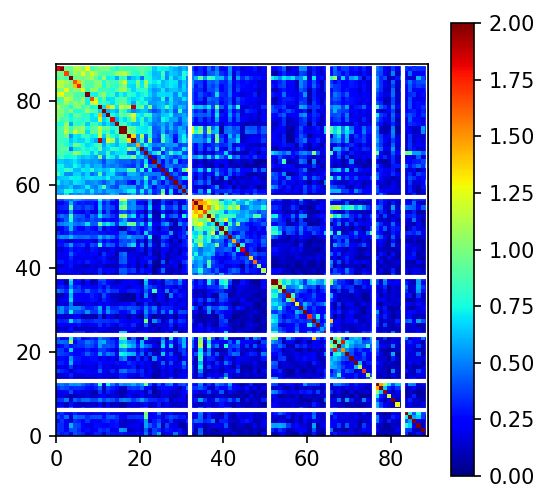

```python
plt.rcParams['figure.figsize'] = 4,4
plt.figure()
plt.imshow(Dsca['Csca'][np.ix_(Dsect['sortedpos'], Dsect['sortedpos'])], \
           vmin=0, vmax=2,cmap = 'jet',interpolation='none',\
           aspect='equal',extent=[0,sum(Dsect['icsize']),\
                                  0,sum(Dsect['icsize'])])
line_index=0
for i in range(Dsect['kpos']):
    plt.plot([line_index+Dsect['icsize'][i],line_index+Dsect['icsize'][i]],\
             [0,sum(Dsect['icsize'])],'w', linewidth = 2)
    plt.plot([0,sum(Dsect['icsize'])],[sum(Dsect['icsize'])-\
            line_index,sum(Dsect['icsize'])-line_index],'w', linewidth = 2)
    line_index += Dsect['icsize'][i]
#plt.title('Positional correlations by contribution to top ICs',fontweight='bold')
plt.colorbar()
plt.savefig('fig_s1a_icHeatmap.pdf',fmt = 'pdf')
```

### A sector is the sub-set of ICs that are not fully indepenent from each other. Signal in the off-diagonals will indicate coupling between a given pair of ICs. Note, that defining sectors in this way is heurisitc.

For the serine protease, the off-diagonals have relatively little signal. This means that serine protease has 6 sectors, one for each IC.

For dihydrofolate reductase, each IC is not fully independent from one another. This means that DHFR has a single sector composed of all significant positions in all of its ICs.

### Grouping ICs into sector(s)

```python
#### DEFINE ICs and colors FOR EACH SECTOR ####################################################################
sector_groups = [[0],[1],[2],[3],[4],[5]]
colors = [0.4,0,0.7,0.15,0.9,0.5] #s1 = green, s2 = red, s3 = blue, s4 = orange, s5 = hot pink, s6 = cyan
##############################################################################################################

sectors = []
#Create class, s, for each sector that goes into the list, sectors.
    # Each class has two objects, col and items.
    #s.col - color for the sector
    #s.items - positions in each IC. Ordered from highest to lowest signal.

for n,sectorICs in enumerate(sector_groups):  #1. iterate through each sector
    s = sca.Unit() #2.initialize class

    all_items = list() #3. initialize list of position indicies
    all_Vp = list() #4. initalize list of positional correlations in each IC

    for i in sectorICs: #5. itereate through each IC in the sector
        all_items = all_items+Dsect['ics'][i].items #6. add indexes of positions each IC in the sector to the list
        all_Vp = all_Vp+list(Dsect['ics'][i].vect) #7. add positional correlations in the IC to the list

    svals = np.argsort(all_Vp) #8. sort positions in sector from gretaest to lowest positional correlation
    s.items = [all_items[i] for i in svals] #9. sort indicies of positions accordingly and save this object to the class.
    s.col = colors[n] #10. save color for the sector as an object to the class
    sectors.append(s)#11. save class to the list of sectors
```

### Plot the IC-ordered SCA matrix $\tilde{C}_{ij}$ grouped according to sectors

The SCA matrix is ordered according to sector and then by positional correlation.

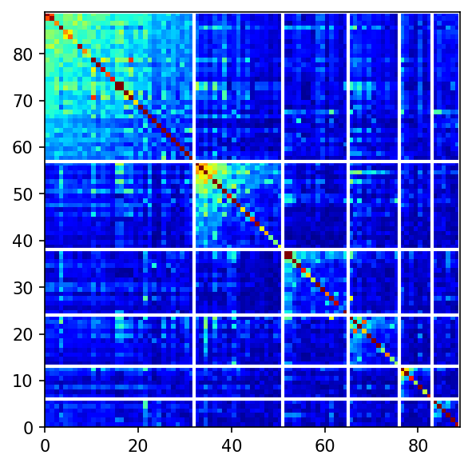

```python
plt.rcParams['figure.figsize'] = 4,4
plt.figure()

line_index=0
sortpos = list()
for s in sectors: #iterate through each sector
    sortpos.extend(s.items) #append all of the positions in the sector to the sortpos list.

#plot sca matrix according to grouping by sectors
plt.imshow(Dsca['Csca'][np.ix_(sortpos, sortpos)], vmin=0, vmax=2.2,interpolation='none',aspect='equal',extent=[0,len(sortpos),0,len(sortpos)],cmap = 'jet')

#iterate through each sector and plot the white lines that separates each sector
for s in sectors:

    plt.plot([line_index+len(s.items),line_index+len(s.items)],[0,len(sortpos)],'w', linewidth = 2)

    plt.plot([0,sum(Dsect['icsize'])],[len(sortpos)-line_index,len(sortpos)-line_index],'w', linewidth = 2)

    line_index += len(s.items)

plt.tight_layout()
plt.savefig('fig_s1a_sectorsHeatmap.pdf',fmt = 'pdf')
```

# 6. Studying the basis of positional correlations with sequence correlations and functional annotations.

##### The sequence correlations are directly related to the positional correlations by the single value decomposition (SVD).

The sequence similarity matrix is decomposed with eigendecomposition and then rotated with $W$,the multiplier that maximized the differences between positional correlaations. This allows for each independent component in the sequence space ($U^{p}_{k}$) to be directly interpretable alongside each indepednent component in the positional space ($V^{p}_{k}$).

For the purposes of this script, I will show how you can analyze sequence correlations according to taxonomic information that was added to the headers of each sequence of the MSA with annotateMSA. These headers are stored in Dseq['hd']. **Note: The following section parses custom headers for the MSA of serine protease, S1A. This parsing must be customized according to the features of each sequence you would like to study in detail.**

## STEP 1. Parsing sequence annotations into dictionaries.

Each sequence in your alignment with a header is stored in Dseq['hd']. In this example, we will parse the headers of the MSA for serine protease, 's1Ahalabi_1470_nosnakes.an'.

*NOTE THAT FOR THE S1A ALIGNMENT, THE FORMATTING OF THE HEADER LOOKS LIKE THIS:*

```
>>>'gi|giNumber|vertebrate or invertebrate|cold or warm blooded|species name|level 0 group|level 1 group|level 2 group|level 3 group'
```

*NOTE THAT FOR THE PFAM DHFR ALIGNMENT, THE FORMATTING OF THE HEADER IS DIFFERENT:*

```
>>>'giNumber|protein name and or EC ID|species name|phylogenetic level 0 group, level 1 group, level 2 group, level 3 group'
```

**You will need to customize how these data are parsed according to the annotations you are interested in studying.***

```python
### S1A SERINE PROTEASE ###########################################################################################
# INITIALIZE dictionaries for the three general classes of information in the headers
annot = dict() #phlogenetic categorization of each sequence
spec = dict() #species information for each sequence
vert = dict() #the sequence comes from an vertebrate or invertebrate

# to vert, initalize a list for each category
vert['vertebrate'] = []
vert['not vertebrate']= []

#now iterate through each header, parse, and fill dictionaries
for headerix, header in enumerate(Dseq['hd']):

    splitHeader = header.split('__') #splits before vertebrate/invertebrate designation
    description = splitHeader[0] #defines giInfo string

    speciesID = splitHeader[0].split('|')[1] #species giNumber
    annotationList = splitHeader[1].split('|') #splits annotation info on the right side of the double underscore into a list of strings

    speciesName = annotationList[2] #defines species identity
    annotationString = ','.join(annotationList[3:-2])

    annot[speciesID] = sca.Annot(description, speciesName, annotationString)
    # for each species, an object was created and stored in annot with the speciesID as the key
        # to pull out information for each species in the dictionary, annot
        # 'giNumber' is a the gi number for the sequence as a string
        # pull out description with: annot['giNumber'].descr
        # pull out SpeciesName with: annot['giNumber'].species
        # pull out annotationString with: annot['giNumber'].taxo

    if speciesName in spec.keys():
        spec[speciesName].append(i)
    else:
        spec[speciesName] = [i]

    if annotationList[0] in vert.keys(): #Does this sequence have a vertebrate/invertebrate identification?
        vert[annotationList[0]].append(i)

    # for each key in the dictionaries spec or vert, a list of indexes of the sequences in the MSA
```

## STEP 2. What are the most frequent taxonomic groups in each phylogenetic level?

```python
atleast = 10 #if there are more than 10 guys in a group, it is frequent

for level in range(4):

    #1. make a list of taxonomic groups that appears in the alignment for a given phylogenetic level (0,1, or 2).
    descr_list = [a.taxo.split(',')[level] for a in annot.values()\
                  if len(a.taxo.split(',')) > level]

    #2. count number of sequences is a given taxonomic group in the alignment
    #3. groups that show up 10 or more times in the alignment get saved into the dictionary
    descr_dict = {k:descr_list.count(k) for k in descr_list \
                  if descr_list.count(k)>=atleast}

    #4. Output most frequently samples groups in each level
    print('\n Level %i:' % level)
    print(descr_dict)
```

[output not shown]

# STEP 3. Now that we have parsed and evaluated the annotations in the S1A alignment, let's continue using this example in highlighting correlations in each of the following categories:

1. Sectors (positional correlations)
2. level 0 taxonomic groups (sequence correlations)
3. vertebrate/invertebrate distinctions (sequence correlations)

To highlight groups in each category, assign legend colors. Normal matplotlib color codings like 'k','r','lightblue', etc, will not work for the plotting function in SCA. To see all the colors and their numberic codes, enter this:

```
>>> sca.figColors()
```

### To see what the SCA color number maps to in the matplotlib color code, use the following functions:

```python
def whatColorIsThis(scaColNum):
    #This takes any number encoding shown in sca.figColors() and
    #converts it into a 3 number color code that matplotlib understands
    #Enter a number no greater than 1

    if scaColNum >= 0 and scaColNum < 1:
        bgr = sca.colorsys.hsv_to_rgb(scaColNum, 1, 1)
    if scaColNum >= 1:
        bgr = [0.3, 0.3, 0.3]
    if scaColNum < 0:
        bgr = [0.7, 0.7, 0.7]
    return bgr

def makeAnnotationLegend(colorList,legendList):
    #this takes a list that contains your list of SCA color numbers and corresponding annotation list
    #allows you to make a legend!
    for six,s in enumerate(colorList):
        plt.title('LEGEND')
        plt.plot(0,six,'o',color = whatColorIsThis(s),markersize=10,markeredgecolor ='k')
        plt.text(0.4,six-0.4,legendList[six],color = 'k',fontweight = 'bold')
    plt.xlim(-1,5)
    plt.ylim(-2,len(colorList)+2)
    plt.xticks([])
    plt.yticks([])
```

**For pulling out a single color from c**

Make sure that: 0 ≤ c ≤ 1

```
0.2777777777777778
```

```
([], <a list of 0 Text yticklabel objects>)
```

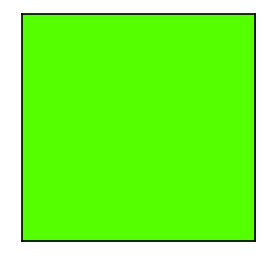

```python
### define number you want to find the SCA color for ######
degree = 100#any number between 0 and 360 (represents position in the circle)
c =  (degree*np.pi/180)/(2*np.pi)
print(c)

############################################################
plt.rcParams['figure.figsize'] = 2,2
plt.figure()
plt.plot([0],[0],'o',color = whatColorIsThis(c),markeredgecolor = 'k',markersize = 1000)
plt.xticks([])
plt.yticks([])
```

**Make a legend for an array of colors**

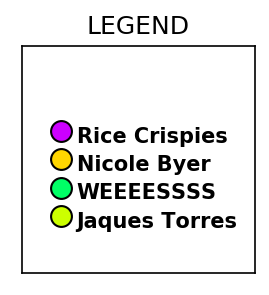

```python
#### DEFINE TWO LISTS OF THE SAME LENGTH ########################

exampleColors = [0.2,0.4,0.14,0.8]
exampleNames = ['Jaques Torres','WEEEESSSS','Nicole Byer', 'Rice Crispies']

################################################################

plt.rcParams['figure.figsize'] = 2,2
plt.figure()
makeAnnotationLegend(exampleColors,exampleNames)
```

## STEP 3.1 Highlighting sectors contributing to positional correlations

**1. make legend that distinguishes positions in each sector**

[figure not shown]

```python
plt.rcParams['figure.figsize'] = 2,2
plt.figure()
makeAnnotationLegend(colors,[1,2,3,4,5,6])
```

### **2. plot scatter plots of IC pairs. Highlight positions in their respective sectors**

For these plots, you must use the function, **sca.figUnits(xvalues, yvalues, list of elements)**

- **xvalues** = positional correlations contributing to IC on x-axis ($V^P_{x}$)
- **yvalues** = positional correlations contributing to IC on y-axis ($V^P_{y}$)
- **list of elements** = list of classes, one for each sector. Each class stores the objects, *col* and *items*.

  *col* is SCA color number for the sector

  *items* is index of positions to be highlighted with the sector color.

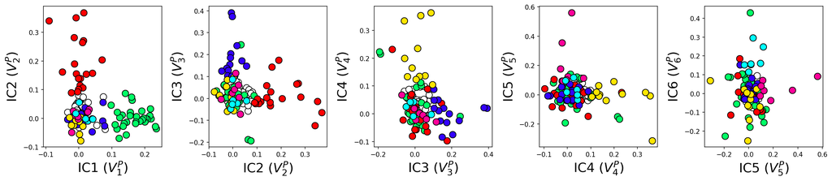

```python
pairs= [[0,1],[1,2],[2,3],[3,4],[4,5]] #1. define pairs of ICs you wish to correlate against each other

plt.rcParams['figure.figsize'] = 18,4
plt.figure()
for n,[k1,k2] in enumerate(pairs): #2. iterate through each pair of ICs
    plt.subplot(1,len(pairs),n+1) #3. define subplot for each pair

    #4. Call sca.figUnit() to make scatter plot that highlights sector positions
    sca.figUnits(Dsect['Vpica'][:,k1], Dsect['Vpica'][:,k2],sectors, dotsize = 10)

    #5. You need to manually add labels.
    plt.xlabel('IC%i ($V^P_{%i}$)' % (k1+1, k1+1), fontsize=20)
    plt.ylabel('IC%i ($V^P_{%i}$)' % (k2+1, k2+1), fontsize=20)

plt.tight_layout()
plt.savefig('fig_icScatter_sectors.pdf')
```

## STEP 3.2 Highlighting sequences of vertebrates/invertebrates contributing to sequence correlations in each IC

Like with sectors...

1. assign colors for each category in the group
2. define class and iterate through each category
3. define the objects in the class: name, col, and items
4. store class to list of classes for the group
5. use list of classes in constructing scatter plots for each IC of sequence correlations

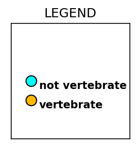

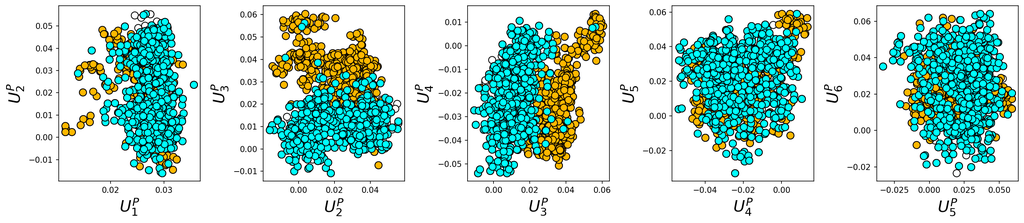

```python
## Create classes for vertebrates/invertebrates#######################################################################

#1. Define categories in the group
vertLabels = ['vertebrate', 'not vertebrate']
#2. Define colors for the group
vertColors = [0.12, 0.5]

vert_classes = []
#Iterate through each item in the dictionary you made above, vert
for i, k in enumerate(vertLabels):

    #1)initialize class
    sf = sca.Unit()
    #2)save category name to the class
    sf.name = vertLabels[i]
    #3)save SCA color number of category to class
    sf.col = vertColors[i]

    #4)go through the alignment and save indexes of sequences in the alignment that are in this category
    sf.items = [j for j,q in enumerate(Dseq['hd'])  if sf.name in q.lower()]

    #5)add category's class to the list
    vert_classes.append(sf)

## Make a legend #####################################################################################################
plt.rcParams['figure.figsize'] = 2,2
makeAnnotationLegend(vertColors, vertLabels)

######################################################################################################################
## Construct scatter plots of ICs in sequence space and highlight sequences that are vertebrates and invertebrates
plt.rcParams['figure.figsize'] = 18,4
u = vert_classes #defines lists of classes to use
plt.figure()
for n,[k1,k2] in enumerate(pairs):
    plt.subplot(1,len(pairs),n+1)
    sca.figUnits(Dsect['Upica'][:,k1],Dsect['Upica'][:,k2], u)
    plt.xlabel('$U^P_{%i}$' %(k1+1),fontsize=20)
    plt.ylabel('$U^P_{%i}$' %(k2+1),fontsize=20)

plt.tight_layout()
```

## STEP 3.3 Highlighting sequences of phylogenetic families contributing to sequence correlations

```
List of colors and list of cateogries are the same length

**Printing out example attributes stored for Actinobacteria**
name:  actinobacteria
col:  0.38
items:  [35, 117, 368, 419, 516, 567, 571, 669, 815, 820, 931, 1029, 1233, 1266]
```

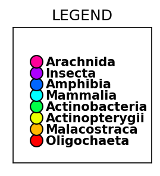

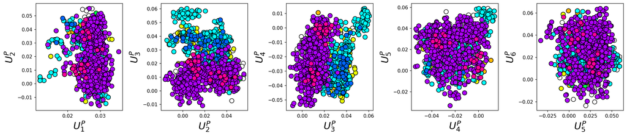

```python
##Create list of classes for each family #############################################################################

#1. Define list of classes for this group
phylo = list()
#2. Define list of categories in the group
fam_names = ['Oligochaeta', 'Malacostraca','Actinopterygii','Actinobacteria',\
            'Mammalia','Amphibia','Insecta','Arachnida']
#3. Define list of colors for each category
family_colors = [0,0.12,0.18,0.38,0.5,0.60,0.78,0.90]


### DHFR #####################################################################################
#fam_names = ['Eukaryota', 'Bacteroidetes', 'Firmicutes','Actinobacteria', 'Proteobacteria']
#family_colors = [0,0.12,0.18,0.38,0.5]
###############################################################################################

#4. List of categories and list of colors must be the same length! Check this with print statement below.
if len(fam_names) == len(family_colors):
    print ('List of colors and list of cateogries are the same length')
else:
    print ('Lists are NOT the same length')

#5. Fill group list with an class for each category
for i,k in enumerate(fam_names):
    #1)initialize class
    sf = sca.Unit()
    #2)save category name to class
    sf.name = fam_names[i].lower()
    #3)save SCA color number of category to class
    sf.col = family_colors[i]

    #4)go through the alignment and save indexes of sequences in the alignment that are in this category
    sf.items = [j for j,q in enumerate(Dseq['hd'])  if sf.name in q.lower()]

    #5)add category's class to the list
    phylo.append(sf)

print (' ')
ex = 'Actinobacteria' #enter category name
exIndex = fam_names.index(ex) #pulls out index of category in list
print ('**Printing out example attributes stored for '+ ex+'**')
print ('name: ', phylo[exIndex].name)
print ('col: ', phylo[exIndex].col)
print ('items: ', phylo[exIndex].items)

## Make a legend #####################################################################################################

plt.rcParams['figure.figsize'] = 2,2
plt.figure()
makeAnnotationLegend(family_colors,fam_names)


##Scatter plots of sequence correlations in each IC and highlight families############################################

u = phylo #defines list of classes to use
plt.rcParams['figure.figsize'] = 18,4

plt.figure()
for n,[k1,k2] in enumerate(pairs):
    plt.subplot(1,len(pairs),n+1)
    sca.figUnits(Dsect['Upica'][:,k1],Dsect['Upica'][:,k2], u)
    plt.xlabel('$U^P_{%i}$' %(k1+1),fontsize=20)
    plt.ylabel('$U^P_{%i}$' %(k2+1),fontsize=20)

plt.tight_layout()
```

## STEP 4. Interpret sectors and phylogenetic groups that underlying S1A positional and sequence correlations.

#### To more easily compare correlations and their underlying annotations, plot them again all in one place. The script below re-plots everything in one place

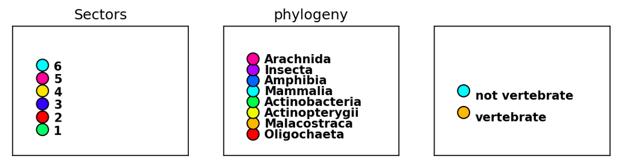

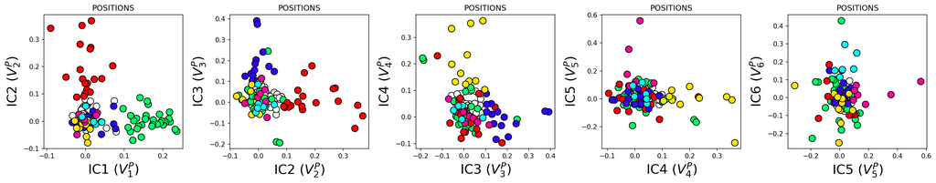

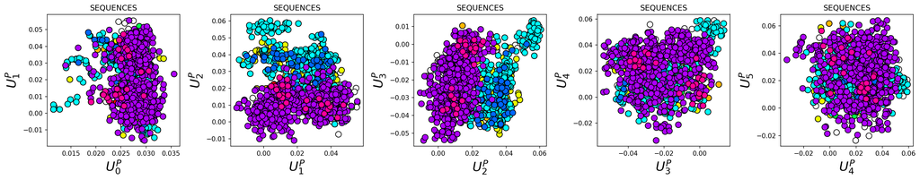

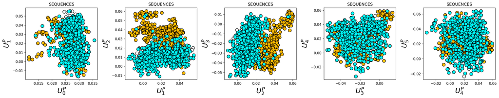

```python
## ANNOTATION LEGENDS ##############################################################################################
#plot legend for sectors to highlight positions each IC
plt.rcParams['figure.figsize'] = 9,2
plt.figure()
plt.subplot(1,3,1)
makeAnnotationLegend(colors,[1,2,3,4,5,6])
plt.title('Sectors')
#legend for invertebrates vs vertebrates
#plot legend for phylogenetic level 1 group to highlight sequences in each IC
plt.subplot(1,3,2)
makeAnnotationLegend(family_colors,fam_names)
plt.title('phylogeny')
plt.subplot(1,3,3)
makeAnnotationLegend(vertColors,vertLabels)

plt.title('')


#### POSITIONAL CORRELATIONS ########################################################################################
#plotting each independent component and highlighting the positions in their respective sectors
plt.rcParams['figure.figsize'] = 20,4

pairs= [[0,1],[1,2],[2,3],[3,4],[4,5]] #pairs of ICs you wish to correlate against each other

plt.figure()
for n,[k1,k2] in enumerate(pairs):
    plt.subplot(1,len(pairs),n+1)

    sca.figUnits(Dsect['Vpica'][:,k1], Dsect['Vpica'][:,k2],sectors, dotsize = 10)
     #sca.figUnits(xvalues, yvalues, list of elements) makes 2D scatter plot and color codes according to object.col

    plt.xlabel('IC%i ($V^P_{%i}$)' % (k1+1, k1+1), fontsize=20)
    plt.ylabel('IC%i ($V^P_{%i}$)' % (k2+1, k2+1), fontsize=20)
    plt.title('POSITIONS')

plt.tight_layout()

#### SEQUENCECE CORRELATIONS ########################################################################################
for u in [phylo,vert_classes]:
    plt.figure()
    for n,[k1,k2] in enumerate(pairs):
        plt.subplot(1,len(pairs),n+1)
        sca.figUnits(Dsect['Upica'][:,k1],Dsect['Upica'][:,k2], u)
        plt.xlabel('$U^P_{%i}$' %(k1),fontsize=20)
        plt.ylabel('$U^P_{%i}$' %(k2),fontsize=20)
        plt.title('SEQUENCES')

    plt.tight_layout()
```

**The question driving this analysis is:** Can the distinctions between vertebrates and invertebrates and/or distinction between phylogenetic groups infer the functional or evolutionary differences between each Sector?

Along IC3, there is a split of correlations between vertebrates (orange) and invertebrates (blue). This split roughly corresponds to divide between blue sector and the remaining positions in the protein. This tells you that there is a feature in the blue sectors that may have emerged after vertebrates diverged from invertebrates. The phylogenetic families belonging to vertebrates and invertebrates recapitulate this distinction of positions in the blue sector emerging separately from the rest of the sequences in the alignment.